# CHIRPS data download and basic manipulation reference guide

## Elaborated by: Juan Miguel Víquez, Daniel Knopp & Jorge Masis

### 1. Install the required packages

```r
    #install.packages("terra")
    #install.packages("rasterVis")
```

Terra is used for methods for spatial data analysis with raster and vector data. More info on Terra: https://cran.r-project.org/web/packages/terra/index.html

### 2. Load the packages in the Rstudio session

```r
    library(rasterVis)
    library(terra)
```

### 3. Create the path for the Chirps dataset

This is the directory in the PC where Chirps is stored, change it to your computer’s directory, accordingly. In my case is:

```r
    path <- "E:/Thao/chirps_monthly"
```

### 4. Read the names of the files and create a list() from them

```r
    Chirps_files <- list.files(path,
                           pattern = NULL,
                           all.files = FALSE,
                           full.names = TRUE)
head(Chirps_files)
```

```
## [1] "E:/Thao/chirps_monthly/chirps-v2.0.1981.01.tif"
## [2] "E:/Thao/chirps_monthly/chirps-v2.0.1981.02.tif"
## [3] "E:/Thao/chirps_monthly/chirps-v2.0.1981.03.tif"
## [4] "E:/Thao/chirps_monthly/chirps-v2.0.1981.04.tif"
## [5] "E:/Thao/chirps_monthly/chirps-v2.0.1981.05.tif"
## [6] "E:/Thao/chirps_monthly/chirps-v2.0.1981.06.tif"
```

```r
tail(Chirps_files)
```

```
## [1] "E:/Thao/chirps_monthly/chirps-v2.0.2020.07.tif"
## [2] "E:/Thao/chirps_monthly/chirps-v2.0.2020.08.tif"
## [3] "E:/Thao/chirps_monthly/chirps-v2.0.2020.09.tif"
## [4] "E:/Thao/chirps_monthly/chirps-v2.0.2020.10.tif"
## [5] "E:/Thao/chirps_monthly/chirps-v2.0.2020.11.tif"
## [6] "E:/Thao/chirps_monthly/chirps-v2.0.2020.12.tif"
```

### 4. Create a stack

More info: https://r-spatial.github.io/stars/

```r
    chirps <- rast(Chirps_files)
chirps
```

```
## class       : SpatRaster
## dimensions  : 2000, 7200, 480  (nrow, ncol, nlyr)
## resolution  : 0.05, 0.05  (x, y)
## extent      : -180, 180, -50, 50  (xmin, xmax, ymin, ymax)
## coord. ref. : lon/lat WGS 84 (EPSG:4326)
## sources     : chirps-v2.0.1981.01.tif
##               chirps-v2.0.1981.02.tif
##               chirps-v2.0.1981.03.tif
##               ... and 477 more source(s)
## names       : chirp~81.01, chirp~81.02, chirp~81.03, chirp~81.04, chirp~81.05, chirp~81.06, ...
```

A raster stack has 3 dimensions (X, Y, Time), each of the rasters have the monthly average precipitation and each of the pixels in these rasters contains the precipitation value on the location for that month. If we want to plot the data, since the stack has 3 dimensions we use variablename[[]] to access a specific time:

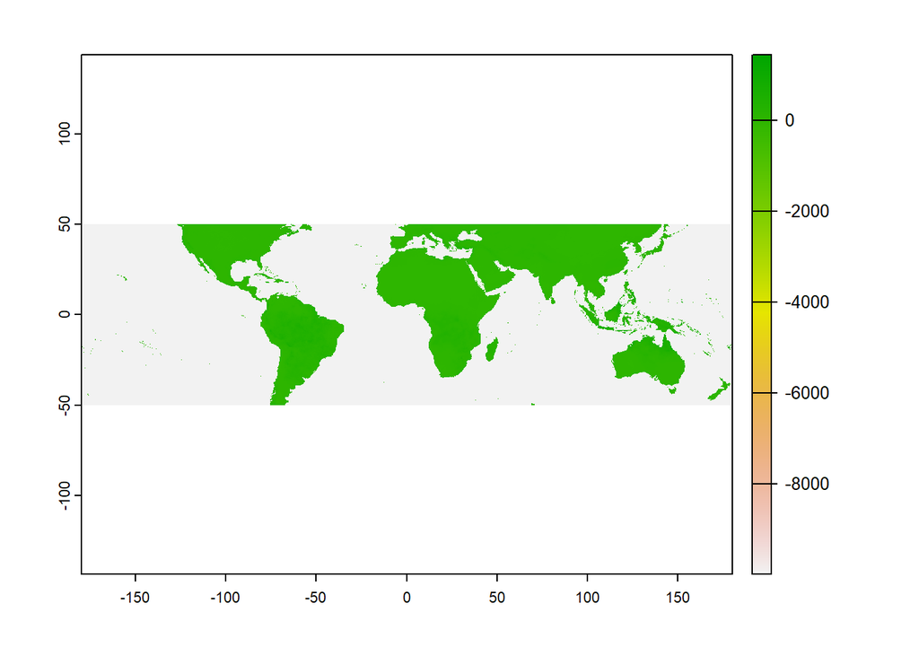

```r
    plot(chirps[[1]])
```

Given that CHIRPS is a global product we need to crop the area to our study region. In order to do this we use a Shapefile as a “cookie cutter” to extract only the within our area of interest. To load a shapefile we use the *vect* function of the terra package **(*Be aware of only using the .shp file and not the others ending on .shx or any other extension)***:

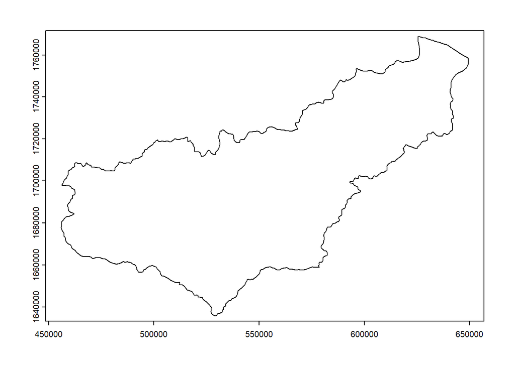

```r
    Aguan_basin_path <- "E:/Basin_Rapel/Aguan/Cuenca_Rio_Aguan.shp"
    Aguan_basin <- vect(Aguan_basin_path)
    plot(Aguan_basin)
```

### Adjusting the reference system of the Spatvector ####if the crs of the stack and the SHP does not match, we need to reproject the shapefile to the coordinates system of the raster, we can check that with

```r
chirps
```

```
## class       : SpatRaster
## dimensions  : 2000, 7200, 480  (nrow, ncol, nlyr)
## resolution  : 0.05, 0.05  (x, y)
## extent      : -180, 180, -50, 50  (xmin, xmax, ymin, ymax)
## coord. ref. : lon/lat WGS 84 (EPSG:4326)
## sources     : chirps-v2.0.1981.01.tif
##               chirps-v2.0.1981.02.tif
##               chirps-v2.0.1981.03.tif
##               ... and 477 more source(s)
## names       : chirp~81.01, chirp~81.02, chirp~81.03, chirp~81.04, chirp~81.05, chirp~81.06, ...
```

```r
Aguan_basin
```

```
##  class       : SpatVector
##  geometry    : polygons
##  dimensions  : 1, 2  (geometries, attributes)
##  extent      : 455933.2, 649466.3, 1635805, 1768898  (xmin, xmax, ymin, ymax)
##  source      : Cuenca_Rio_Aguan.shp
##  coord. ref. : NAD27 / UTM zone 16N (EPSG:26716)
##  names       :    ID         NOM_CUEN
##  type        : <int>            <chr>
##  values      :    33 Cuenca Rio Aguán
```

####If the stack and the SHP are in a diferent coordinate system, we solve this with the project() function ####More info on https://rdrr.io/cran/terra/man/project.html

```r
  Aguan_basin<-project(Aguan_basin,"+proj=longlat +datum=WGS84")
Aguan_basin
```

```
##  class       : SpatVector
##  geometry    : polygons
##  dimensions  : 1, 2  (geometries, attributes)
##  extent      : -87.41018, -85.60386, 14.79805, 15.99829  (xmin, xmax, ymin, ymax)
##  coord. ref. : +proj=longlat +datum=WGS84 +no_defs
##  names       :    ID         NOM_CUEN
##  type        : <int>            <chr>
##  values      :    33 Cuenca Rio Aguán
```

### 5. We can start to cut our study area

For this, we need to use 2 functions. The first one is *crop()* (more info on https://rdrr.io/cran/terra/man/crop.html)

```r
    chirps_crop <- crop(chirps, Aguan_basin, snap = 'out')
chirps_crop
```

```
## class       : SpatRaster
## dimensions  : 25, 37, 480  (nrow, ncol, nlyr)
## resolution  : 0.05, 0.05  (x, y)
## extent      : -87.45, -85.6, 14.75, 16  (xmin, xmax, ymin, ymax)
## coord. ref. : lon/lat WGS 84 (EPSG:4326)
## source      : memory
## names       : chirp~81.01, chirp~81.02, chirp~81.03, chirp~81.04, chirp~81.05, chirp~81.06, ...
## min values  :  -9999.0000,  -9999.0000,   -9999.000, -9999.00000,  -9999.0000,  -9999.0000, ...
## max values  :    215.6551,    520.1174,     141.909,    91.17754,    182.3561,    349.6431, ...
```

Plot the data

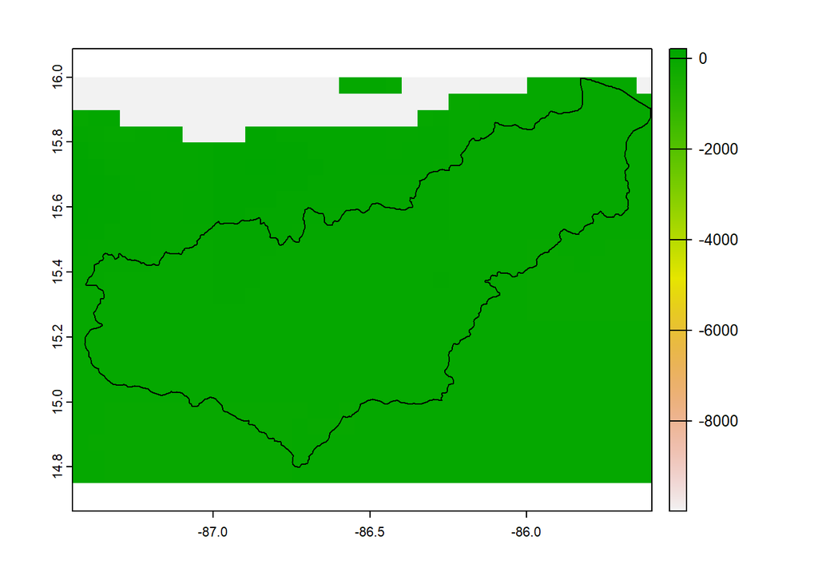

```r
    plot(chirps_crop[[1]])

##Show the outline of the basin

    lines(Aguan_basin)
```

The second function is *mask()*, this one eliminates any NA’s resulting from the crop. *(Always crop first and mask second, otherwise you will try to mask the whole extend of the datasheet and it takes a lot of processing and thus time)*

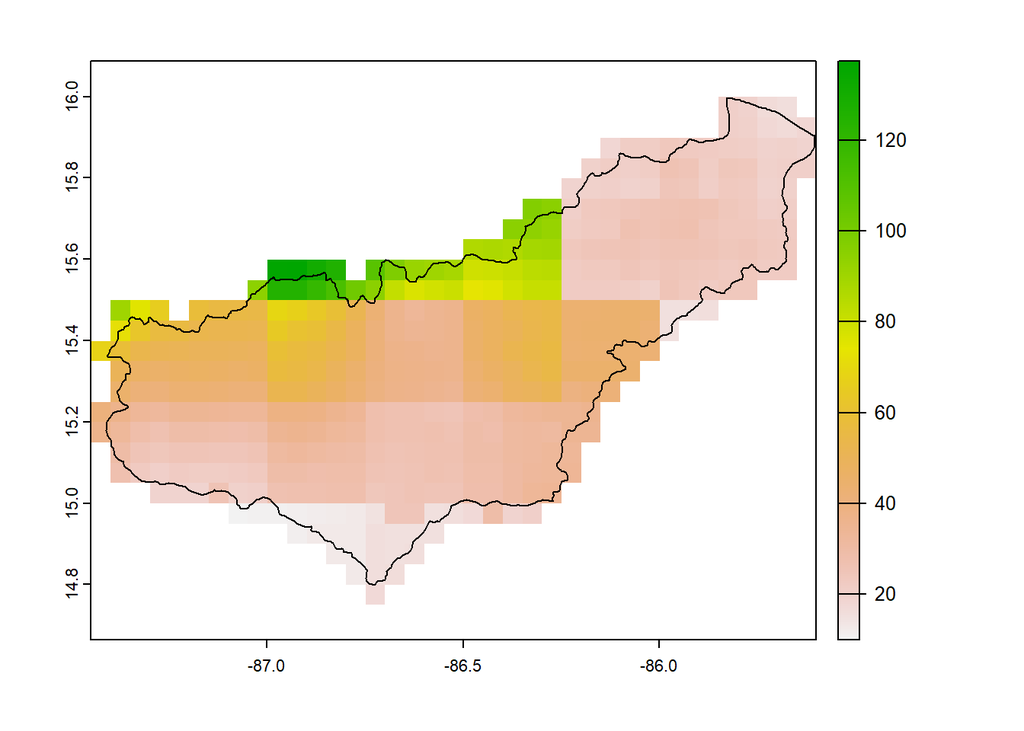

```r
    chirps_aguan <- mask(chirps_crop, Aguan_basin)
    plot(chirps_aguan[[1]])
    lines(Aguan_basin)
```

### 6. Get a monthly average plot and monthly string

With *tapp()* we will grab the cropped raster stack and average for the index time period, then in order to get the monthly average we need to use an *index=1:12*, with that done we can assign the names of the months to the raster layer

```r
    monthly_chirps<-tapp(chirps_aguan, index = 1:12, fun = mean)
    names(monthly_chirps)<-c('Jan','Feb','Mar','Apr','May','Jun','Jul','Aug','Sep','Oct','Nov','Dec')
    monthly_chirps
```

```
## class       : SpatRaster
## dimensions  : 25, 37, 12  (nrow, ncol, nlyr)
## resolution  : 0.05, 0.05  (x, y)
## extent      : -87.45, -85.6, 14.75, 16  (xmin, xmax, ymin, ymax)
## coord. ref. : lon/lat WGS 84 (EPSG:4326)
## source      : memory
## names       :       Jan,      Feb,      Mar,      Apr,       May,       Jun, ...
## min values  :  21.52865,  20.7853,  13.5531, 17.69893,  79.88621,  97.11658, ...
## max values  : 207.26403, 162.3048, 119.6022, 53.04014, 151.10059, 195.20016, ...
```

Next, we are make a *levelplot* for the monthly averages (see https://www.rdocumentation.org/packages/lattice/versions/0.10-10/topics/levelplot)

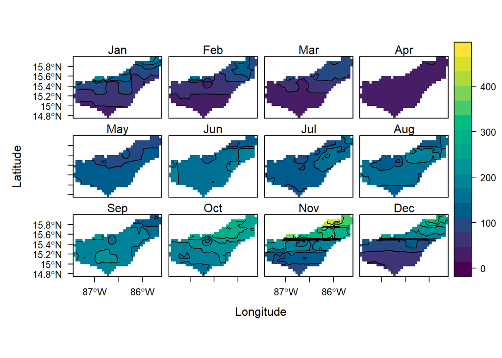

```r
    levelplot( monthly_chirps,layout=c(4,3),contour=T,col.regions=hcl.colors(100))
```

### 7. Extract mean precipitation This takes the already cropped and masked stack for extracting the values inside a specific shapefile.

```r
    extracted_values <- extract(chirps_aguan,Aguan_basin, fun = "mean")
extracted_values
```

```
##   ID chirps.v2.0.1981.01 chirps.v2.0.1981.02 chirps.v2.0.1981.03
## 1  1            37.15697            110.3783            36.37581
##   chirps.v2.0.1981.04 chirps.v2.0.1981.05 chirps.v2.0.1981.06
## 1            24.26153            118.3073            219.8932
##   chirps.v2.0.1981.07 chirps.v2.0.1981.08 chirps.v2.0.1981.09
## 1            135.4949            178.0695            180.1076
##   chirps.v2.0.1981.10 chirps.v2.0.1981.11 chirps.v2.0.1981.12
## 1            180.2645            160.9126             154.746
##   chirps.v2.0.1982.01 chirps.v2.0.1982.02 chirps.v2.0.1982.03
## 1            52.59569            78.24516            60.55556
##   chirps.v2.0.1982.04 chirps.v2.0.1982.05 chirps.v2.0.1982.06
## 1            24.87789            195.6334            231.6801
##   chirps.v2.0.1982.07 chirps.v2.0.1982.08 chirps.v2.0.1982.09
## 1            167.3567            162.1917            209.4081
##   chirps.v2.0.1982.10 chirps.v2.0.1982.11 chirps.v2.0.1982.12
## 1            203.0651             138.445            146.1284
##   chirps.v2.0.1983.01 chirps.v2.0.1983.02 chirps.v2.0.1983.03
## 1            74.67722            44.54071            35.52152
##   chirps.v2.0.1983.04 chirps.v2.0.1983.05 chirps.v2.0.1983.06
## 1             33.5899            46.02689            219.6366
##   chirps.v2.0.1983.07 chirps.v2.0.1983.08 chirps.v2.0.1983.09
## 1            190.5868             181.621            164.6512
##   chirps.v2.0.1983.10 chirps.v2.0.1983.11 chirps.v2.0.1983.12
## 1            273.5114            170.0813            165.0077
##   chirps.v2.0.1984.01 chirps.v2.0.1984.02 chirps.v2.0.1984.03
## 1            91.06231            96.48231            66.11329
##   chirps.v2.0.1984.04 chirps.v2.0.1984.05 chirps.v2.0.1984.06
## 1            37.95225            137.1963            176.5914
##   chirps.v2.0.1984.07 chirps.v2.0.1984.08 chirps.v2.0.1984.09
## 1            208.4602            168.6978            233.8781
##   chirps.v2.0.1984.10 chirps.v2.0.1984.11 chirps.v2.0.1984.12
## 1            170.6794            112.9849            99.06308
##   chirps.v2.0.1985.01 chirps.v2.0.1985.02 chirps.v2.0.1985.03
## 1            57.36449            84.85859            62.78369
##   chirps.v2.0.1985.04 chirps.v2.0.1985.05 chirps.v2.0.1985.06
## 1            31.97358            114.4234            142.3295
##   chirps.v2.0.1985.07 chirps.v2.0.1985.08 chirps.v2.0.1985.09
## 1            132.0556            127.3856            144.4985
##   chirps.v2.0.1985.10 chirps.v2.0.1985.11 chirps.v2.0.1985.12
## 1            226.6466            147.7143             112.764
```

[output cut: 265 more lines]

```
## 1            73.06517            56.79863            28.43611
##   chirps.v2.0.2019.04 chirps.v2.0.2019.05 chirps.v2.0.2019.06
## 1            51.69472            74.48622             90.0304
##   chirps.v2.0.2019.07 chirps.v2.0.2019.08 chirps.v2.0.2019.09
## 1            66.47758            74.21487            132.2606
##   chirps.v2.0.2019.10 chirps.v2.0.2019.11 chirps.v2.0.2019.12
## 1            114.9302            157.4725            96.70894
##   chirps.v2.0.2020.01 chirps.v2.0.2020.02 chirps.v2.0.2020.03
## 1            68.63011            77.79439            53.28366
##   chirps.v2.0.2020.04 chirps.v2.0.2020.05 chirps.v2.0.2020.06
## 1            11.35899             230.028            155.7009
##   chirps.v2.0.2020.07 chirps.v2.0.2020.08 chirps.v2.0.2020.09
## 1            110.5023            148.8008            202.8036
##   chirps.v2.0.2020.10 chirps.v2.0.2020.11 chirps.v2.0.2020.12
## 1            441.0665            790.0389            191.6087
```

We transform the list into a *dataframe* and then transpose, this way we can get a *date/value* format The first line is avoided, as it corresponds to the rows name:

```r
    extracted_values <- as.numeric(extracted_values[2:481])
    values <- as.data.frame(extracted_values)
    values
```

```
##     extracted_values
## 1           37.15697
## 2          110.37832
## 3           36.37581
## 4           24.26153
## 5          118.30733
## 6          219.89325
## 7          135.49488
## 8          178.06949
## 9          180.10761
## 10         180.26454
## 11         160.91257
## 12         154.74602
## 13          52.59569
## 14          78.24516
```

[output cut: 466 more lines]

Following this, we can create a vector from the starting month to the last one. Using the file *basename* (i.e. “chirps-v2.0.2020.09.tif”) we select from 2020 to 09 and use that to create a vector

```r
    Dates <- substr(basename(Chirps_files), 13, 19)
head(Dates)
```

```
## [1] "1981.01" "1981.02" "1981.03" "1981.04" "1981.05" "1981.06"
```

The next step is to attach the dates and the *extracted_values* in a table

```r
    Precipitation_Aguan <- cbind(Dates, values)
Precipitation_Aguan
```

```
##       Dates extracted_values
## 1   1981.01         37.15697
## 2   1981.02        110.37832
## 3   1981.03         36.37581
## 4   1981.04         24.26153
## 5   1981.05        118.30733
## 6   1981.06        219.89325
## 7   1981.07        135.49488
## 8   1981.08        178.06949
## 9   1981.09        180.10761
## 10  1981.10        180.26454
## 11  1981.11        160.91257
## 12  1981.12        154.74602
## 13  1982.01         52.59569
## 14  1982.02         78.24516
```

[output cut: 466 more lines]

Another method is creating a point layer and extract the locations from there

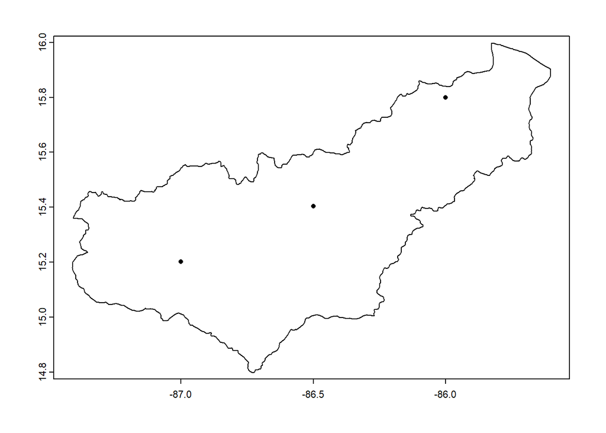

```r
xy <- cbind(c(-87.000,-86.500,-86.000),c(15.202,15.403,15.800))
p <- vect(xy, crs="+proj=longlat +datum=WGS84")
plot(Aguan_basin)
points(p)
```